# R Notebook sandbox: Playing with PCA

# 1 Top of the world

Some of you may have difficulties accessing Wikipedia (e.g., out of the country, or whatever). The notebook should benefit you in your efforts (especially for project 2); however, I have uploaded the concluding data frames:

http://md5.mshaffer.com/WSU_STATS419/_data_/state-capitals/

or

http://md5.mshaffer.com/WSU_STATS419/_data_/state-capitals/final/

You can access them there, if need be.

# 2 Principle Components Analysis

Mathematically, a n-dimensional space can be transformed using a variety of techniques that are mathematically equivalent. This is the concept of a vector having a basis.

So if I have 2-dimensional data, I can transform it into a new basis, still having 2-dimensions.

And if I have 3-dimensional data, I can transform it into a new basis, still having 3-dimensions.

…

And if I have 7-dimensional data, I can transform it into a new basis, still having 7-dimensions.

…

And if I have n-dimensional data, I can transform it into a new basis, still having n-dimensions.

## 2.1 2-Dimensions

### 2.1.1 Elliptical

If the variances would be equal, these ellipses would be circles.

```r
# cache.rebuild ... This will prevent Xs from being used from previous cache ...

library(mvnfast);
source_url( paste0(path.github, "humanVerseWSU/R/functions-maths.R") );   # deg2rad
```

```
## SHA-1 hash of file is 9a32157931ca9357a67a2f32f806f2febac34aad
```

```r
                                          # zeroIsh

set.seed(1222015);

mu = c(1,3); # centers for x,y
Sigma = diag(c(2,23)); # variance for x,y

nsim = 9000;
X = rmvn(nsim, mu, Sigma, ncores=2);  # this is parallelizability with cores
# ncores    ... Number of cores used. The parallelization will take place only if OpenMP is supported.

xy.lim = c(min(X), max(X)); # square

print("################   X   ################");
```

```
## [1] "################   X   ################"
```

```r
print(paste0("MEANS:    x = ",round(mean(X[,1]),3),
                "       y = ",round(mean(X[,2]),3) ));
```

```
## [1] "MEANS:    x = 1.032       y = 3.029"
```

```r
print(paste0("VARIANCE: x = ",round(var(X[,1]),3),
                "       y = ",round(var(X[,2]),3) ));
```

```
## [1] "VARIANCE: x = 1.965       y = 22.735"
```

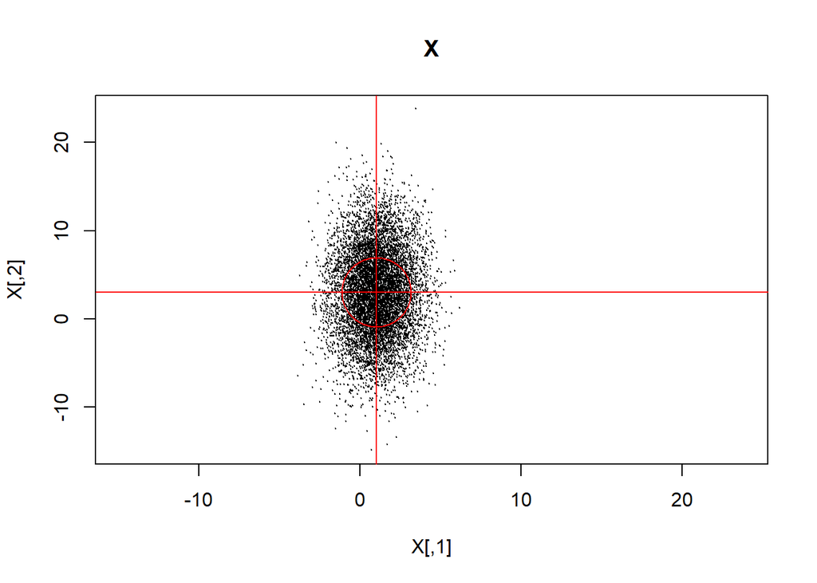

```r
plot(X, pch=20, cex=0.25, main="X",
        xlim=xy.lim, ylim=xy.lim );
  abline(v=mean(X[,1]), col="red");
  abline(h=mean(X[,2]), col="red");
points(x=mean(X[,1]),y=mean(X[,2]),
          pch=21, col="red", cex=8);
```

```r
Xs = scale(X);

print("################   Xs   ################");
```

```
## [1] "################   Xs   ################"
```

```r
print(paste0("MEANS:    x = ",round(mean(Xs[,1]),3),
                "       y = ",round(mean(Xs[,2]),3) ));
```

```
## [1] "MEANS:    x = 0       y = 0"
```

```r
print(paste0("VARIANCE: x = ",round(var(Xs[,1]),3),
                "       y = ",round(var(Xs[,2]),3) ));
```

```
## [1] "VARIANCE: x = 1       y = 1"
```

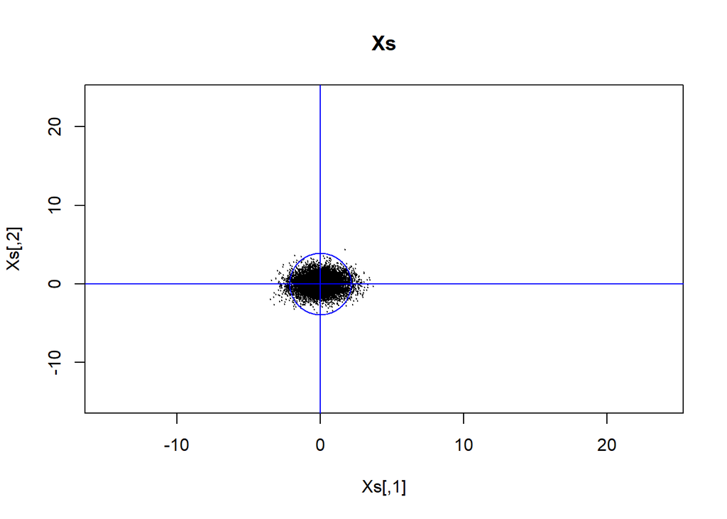

```r
plot(Xs, pch=20, cex=0.25, main="Xs",
        xlim=xy.lim, ylim=xy.lim );
  abline(v=mean(Xs[,1]), col="blue");
  abline(h=mean(Xs[,2]), col="blue");
points(x=mean(Xs[,1]),y=mean(Xs[,2]),
          pch=21, col="blue", cex=8);
```

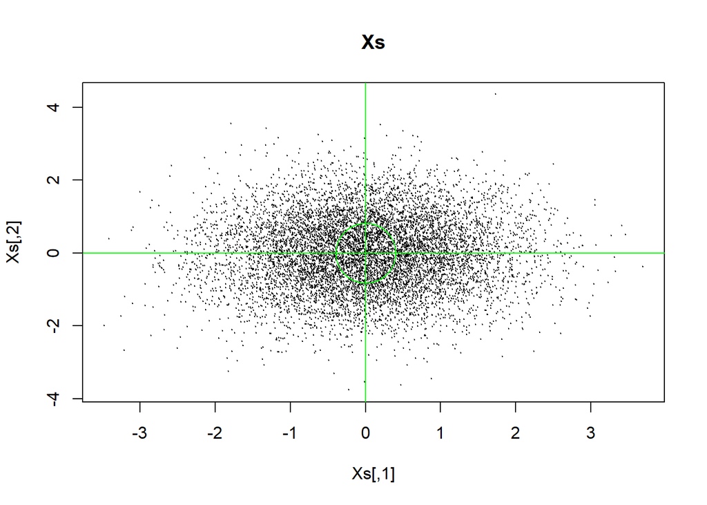

```r
plot(Xs, pch=20, cex=0.25, main="Xs");
  abline(v=mean(Xs[,1]), col="green");
  abline(h=mean(Xs[,2]), col="green");
points(x=mean(Xs[,1]),y=mean(Xs[,2]),
          pch=21, col="green", cex=8);
```

It is called “scaling” for a reason. A translation in the (x,y) to “mean-center” at zero. And a scaling factor of (x,y) … e.g., our z-scores.

I keep the `xlim` and `ylim` the same to see this (“red” vs “blue”). Then I let “green” auto-scale, although it is equal to “blue”.

### 2.1.2 Rotated

We can take that same data and rotate it … eventually we will call this `phi` … currently, hardcoded as $\phi = 60$ in degrees, so I have the helper functions which I have placed in `functions-maths.R`.

```r
x = X[,1];
y = X[,2];

XR = X; # let's manually rotate 60 ...

XR[,1] = x * cos(deg2rad(60)) - y * sin(deg2rad(60));
XR[,2] = x * sin(deg2rad(60)) + y * cos(deg2rad(60));

xyr.lim = c(min(XR),max(XR));

print("################   XR   ################");
```

```
## [1] "################   XR   ################"
```

```r
print(paste0("MEANS:    x = ",round(mean(XR[,1]),3),
                "       y = ",round(mean(XR[,2]),3) ));
```

```
## [1] "MEANS:    x = -2.107       y = 2.408"
```

```r
print(paste0("VARIANCE: x = ",round(var(XR[,1]),3),
                "       y = ",round(var(XR[,2]),3) ));
```

```
## [1] "VARIANCE: x = 17.39       y = 7.31"
```

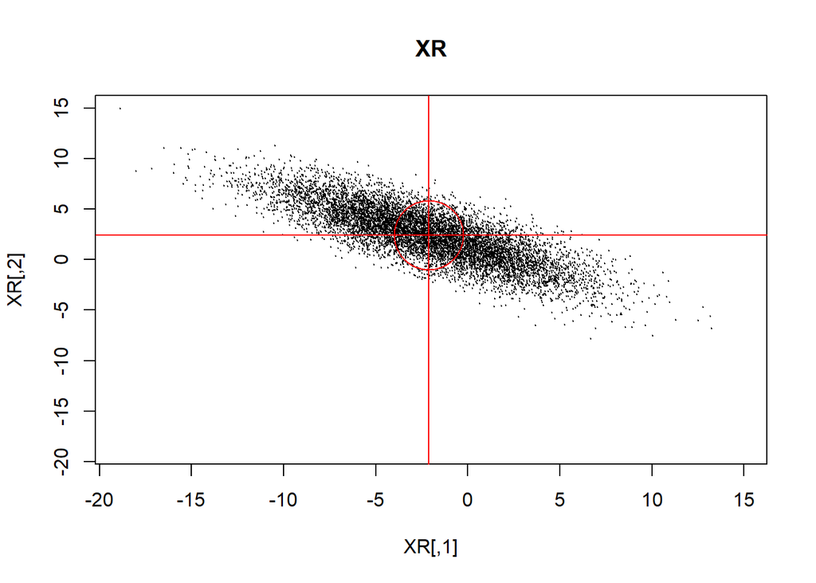

```r
plot(XR, pch=20, cex=0.25, main="XR",
        xlim=xyr.lim, ylim=xyr.lim );
  abline(v=mean(XR[,1]), col="red");
  abline(h=mean(XR[,2]), col="red");
points(x=mean(XR[,1]),y=mean(XR[,2]),
          pch=21, col="red", cex=8);
```

```r
XRs = scale(XR);

print("################   XRs   ################");
```

```
## [1] "################   XRs   ################"
```

```r
print(paste0("MEANS:    x = ",round(mean(XRs[,1]),3),
                "       y = ",round(mean(XRs[,2]),3) ));
```

```
## [1] "MEANS:    x = 0       y = 0"
```

```r
print(paste0("VARIANCE: x = ",round(var(XRs[,1]),3),
                "       y = ",round(var(XRs[,2]),3) ));
```

```
## [1] "VARIANCE: x = 1       y = 1"
```

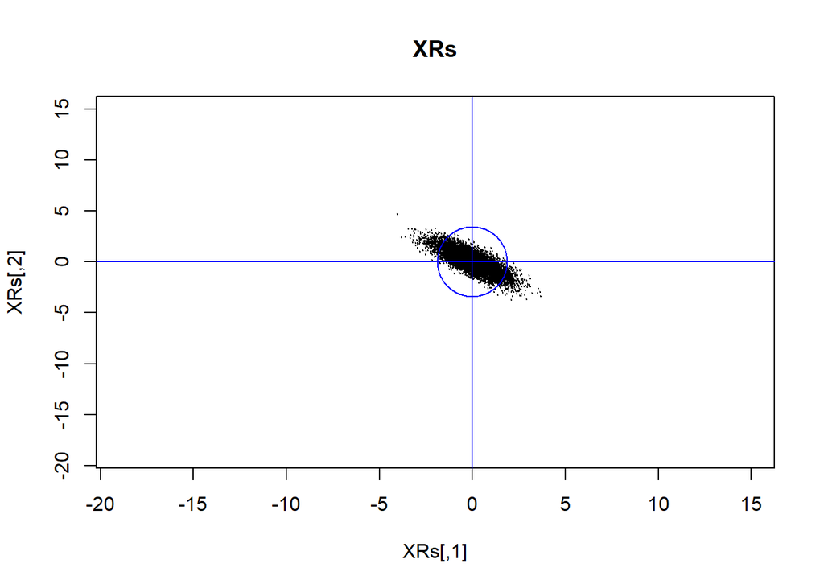

```r
plot(XRs, pch=20, cex=0.25, main="XRs",
        xlim=xyr.lim, ylim=xyr.lim );
  abline(v=mean(XRs[,1]), col="blue");
  abline(h=mean(XRs[,2]), col="blue");
points(x=mean(XRs[,1]),y=mean(XRs[,2]),
          pch=21, col="blue", cex=8);
```

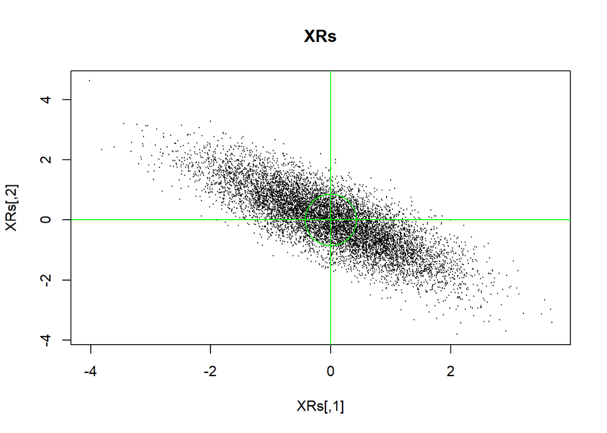

```r
plot(XRs, pch=20, cex=0.25, main="XRs");
  abline(v=mean(XRs[,1]), col="green");
  abline(h=mean(XRs[,2]), col="green");
points(x=mean(XRs[,1]),y=mean(XRs[,2]),
          pch=21, col="green", cex=8);
```

Translations, scalings, and rotations are not changing the overall basis.

### 2.1.3 Principle Components Analysis of Xs

If we don’t scale, the one dimension will outweigh another dimension. This will create uninterpretable results.

#### 2.1.3.1 Xs

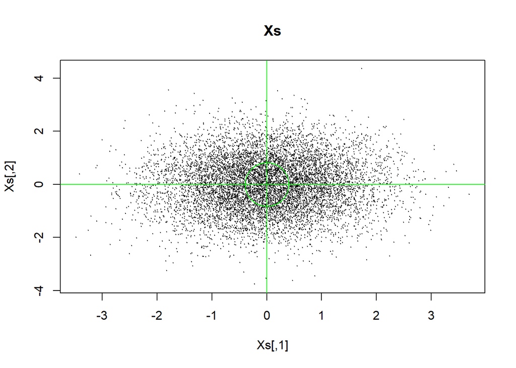

```r
plot(Xs, pch=20, cex=0.25, main="Xs");
  abline(v=mean(Xs[,1]), col="green");
  abline(h=mean(Xs[,2]), col="green");
points(x=mean(Xs[,1]),y=mean(Xs[,2]),
          pch=21, col="green", cex=8);
```

```r
Xs.PCA = princomp(Xs);

summary(Xs.PCA);
```

```
## Importance of components:
##                           Comp.1    Comp.2
## Standard deviation     1.0130539 0.9866608
## Proportion of Variance 0.5131961 0.4868039
## Cumulative Proportion  0.5131961 1.0000000
```

```r
str(Xs.PCA);
```

```
## List of 7
##  $ sdev    : Named num [1:2] 1.013 0.987
##   ..- attr(*, "names")= chr [1:2] "Comp.1" "Comp.2"
##  $ loadings: 'loadings' num [1:2, 1:2] 0.707 0.707 0.707 -0.707
##   ..- attr(*, "dimnames")=List of 2
##   .. ..$ : NULL
##   .. ..$ : chr [1:2] "Comp.1" "Comp.2"
##  $ center  : num [1:2] 0.0000000000000000552 -0.0000000000000000431
##  $ scale   : num [1:2] 1 1
##  $ n.obs   : int 9000
##  $ scores  : num [1:9000, 1:2] 0.844 -1.016 -0.19 0.959 -0.657 ...
##   ..- attr(*, "dimnames")=List of 2
##   .. ..$ : NULL
##   .. ..$ : chr [1:2] "Comp.1" "Comp.2"
##  $ call    : language princomp(x = Xs)
##  - attr(*, "class")= chr "princomp"
```

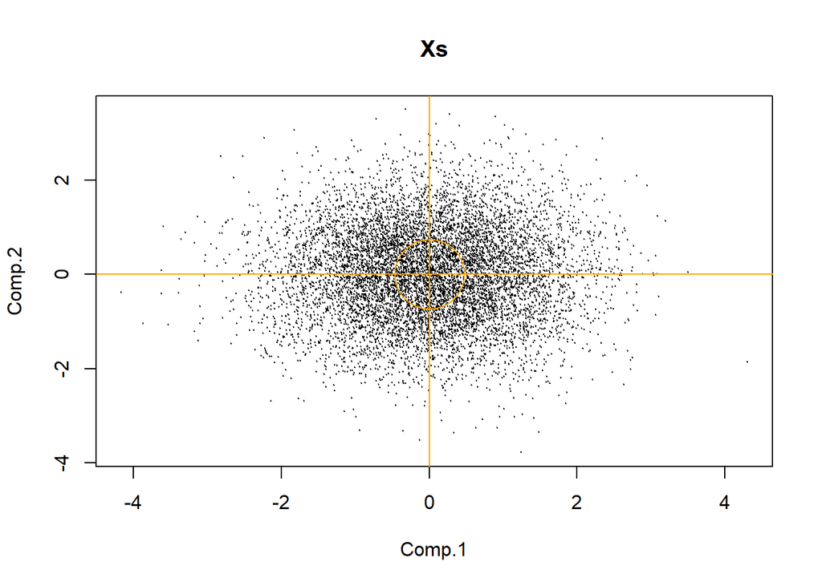

```r
Xs.PCA.scores = Xs.PCA$scores;

plot(Xs.PCA.scores, pch=20, cex=0.25, main="Xs");
  abline(v=mean(Xs.PCA.scores[,1]), col="orange");
  abline(h=mean(Xs.PCA.scores[,2]), col="orange");
points(x=mean(Xs.PCA.scores[,1]),y=mean(Xs.PCA.scores[,2]),
          pch=21, col="orange", cex=8);
```

```r
# Xs.PCA

# XR[,1] = x * cos(deg2rad(60)) - y * sin(deg2rad(60));
```

#### 2.1.3.2 XRs

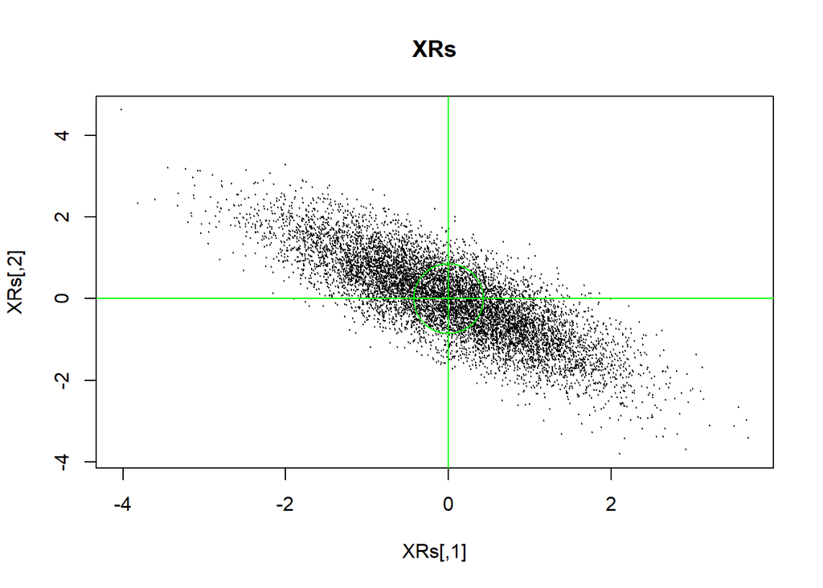

```r
plot(XRs, pch=20, cex=0.25, main="XRs");
  abline(v=mean(XRs[,1]), col="green");
  abline(h=mean(XRs[,2]), col="green");
points(x=mean(XRs[,1]),y=mean(XRs[,2]),
          pch=21, col="green", cex=8);
```

```r
XRs.PCA = princomp(XRs);

summary(XRs.PCA);
```

```
## Importance of components:
##                           Comp.1     Comp.2
## Standard deviation     1.3436177 0.44098663
## Proportion of Variance 0.9027546 0.09724541
## Cumulative Proportion  0.9027546 1.00000000
```

```r
str(XRs.PCA);
```

```
## List of 7
##  $ sdev    : Named num [1:2] 1.344 0.441
##   ..- attr(*, "names")= chr [1:2] "Comp.1" "Comp.2"
##  $ loadings: 'loadings' num [1:2, 1:2] 0.707 -0.707 0.707 0.707
##   ..- attr(*, "dimnames")=List of 2
##   .. ..$ : NULL
##   .. ..$ : chr [1:2] "Comp.1" "Comp.2"
##  $ center  : num [1:2] -0.0000000000000000428 -0.0000000000000000359
##  $ scale   : num [1:2] 1 1
##  $ n.obs   : int 9000
##  $ scores  : num [1:9000, 1:2] -1.351 0.757 0.23 0.188 1.426 ...
##   ..- attr(*, "dimnames")=List of 2
##   .. ..$ : NULL
##   .. ..$ : chr [1:2] "Comp.1" "Comp.2"
##  $ call    : language princomp(x = XRs)
##  - attr(*, "class")= chr "princomp"
```

```r
summary(XRs.PCA);
```

```
## Importance of components:
##                           Comp.1     Comp.2
## Standard deviation     1.3436177 0.44098663
## Proportion of Variance 0.9027546 0.09724541
## Cumulative Proportion  0.9027546 1.00000000
```

```r
str(Xs.PCA);
```

```
## List of 7
##  $ sdev    : Named num [1:2] 1.013 0.987
##   ..- attr(*, "names")= chr [1:2] "Comp.1" "Comp.2"
##  $ loadings: 'loadings' num [1:2, 1:2] 0.707 0.707 0.707 -0.707
##   ..- attr(*, "dimnames")=List of 2
##   .. ..$ : NULL
##   .. ..$ : chr [1:2] "Comp.1" "Comp.2"
##  $ center  : num [1:2] 0.0000000000000000552 -0.0000000000000000431
##  $ scale   : num [1:2] 1 1
##  $ n.obs   : int 9000
##  $ scores  : num [1:9000, 1:2] 0.844 -1.016 -0.19 0.959 -0.657 ...
##   ..- attr(*, "dimnames")=List of 2
##   .. ..$ : NULL
##   .. ..$ : chr [1:2] "Comp.1" "Comp.2"
##  $ call    : language princomp(x = Xs)
##  - attr(*, "class")= chr "princomp"
```

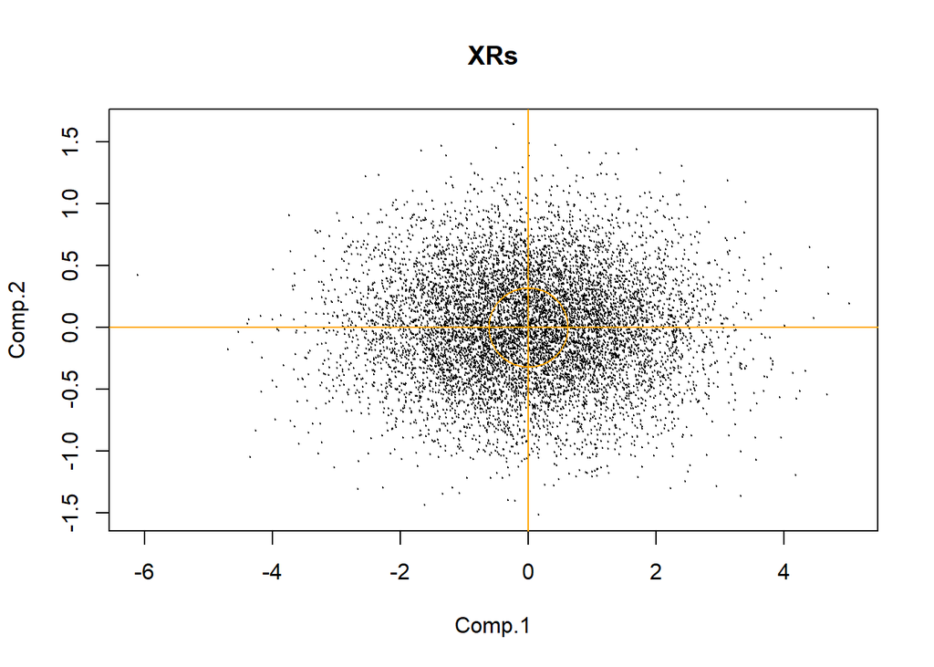

```r
XRs.PCA.scores = XRs.PCA$scores;

plot(XRs.PCA.scores, pch=20, cex=0.25, main="XRs");
  abline(v=mean(XRs.PCA.scores[,1]), col="orange");
  abline(h=mean(XRs.PCA.scores[,2]), col="orange");
points(x=mean(XRs.PCA.scores[,1]),y=mean(XRs.PCA.scores[,2]),
          pch=21, col="orange", cex=8);
```

## 2.2 3-Dimensions

### 2.2.1 Elliptical

If the variances would be equal, these ellipses would be circles.

```r
# cache.rebuild ... This will prevent Xs from being used from previous cache ...

library(scatterplot3d);
library(rgl);

set.seed(1222015);

mu = c(1,3,8); # centers for x,y
Sigma = diag(c(2,23,13)); # variance for x,y

X = rmvn(nsim, mu, Sigma, ncores=2);  # this is parallelizability with cores

xyz.lim = c(min(X), max(X)); # square

print("################   X   ################");
```

```
## [1] "################   X   ################"
```

```r
print(paste0("MEANS:    x = ",round(mean(X[,1]),3),
                "       y = ",round(mean(X[,2]),3),
                "       z = ",round(mean(X[,3]),3)));
```

```
## [1] "MEANS:    x = 1.015       y = 3.043       z = 7.94"
```

```r
print(paste0("VARIANCE: x = ",round(var(X[,1]),3),
                "       y = ",round(var(X[,2]),3),
                "       z = ",round(var(X[,3]),3)));
```

```
## [1] "VARIANCE: x = 2.003       y = 22.924       z = 12.666"
```

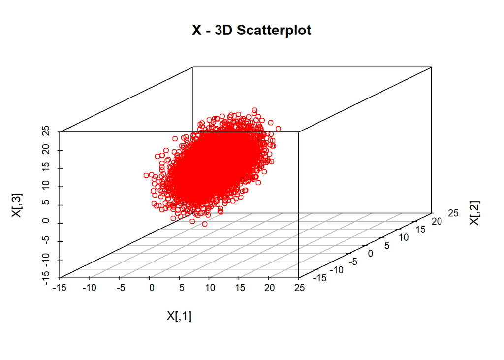

```r
scatterplot3d(X, xlim=xyz.lim, ylim=xyz.lim, zlim=xyz.lim, highlight.3d=FALSE, main="X - 3D Scatterplot", color="red" );
```

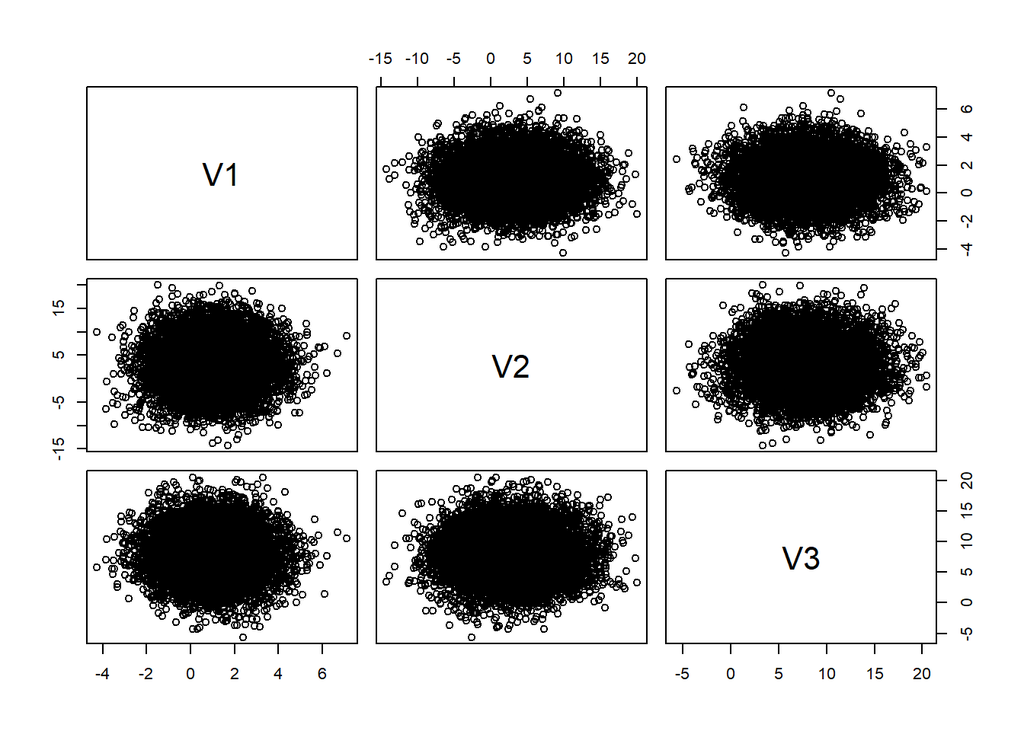

```r
# this is interactive, and will open in its own window
plot3d(X, xlim=xyz.lim, ylim=xyz.lim, zlim=xyz.lim, main="X - 3D plot",col="red" );

graphics::plot( as.data.frame(X) );
```

```r
Xs = scale(X);

print("################   Xs   ################");
```

```
## [1] "################   Xs   ################"
```

```r
print(paste0("MEANS:    x = ",round(mean(Xs[,1]),3),
                "       y = ",round(mean(Xs[,2]),3),
                "       z = ",round(mean(Xs[,3]),3)));
```

```
## [1] "MEANS:    x = 0       y = 0       z = 0"
```

```r
print(paste0("VARIANCE: x = ",round(var(Xs[,1]),3),
                "       y = ",round(var(Xs[,2]),3),
                "       z = ",round(var(Xs[,3]),3)));
```

```
## [1] "VARIANCE: x = 1       y = 1       z = 1"
```

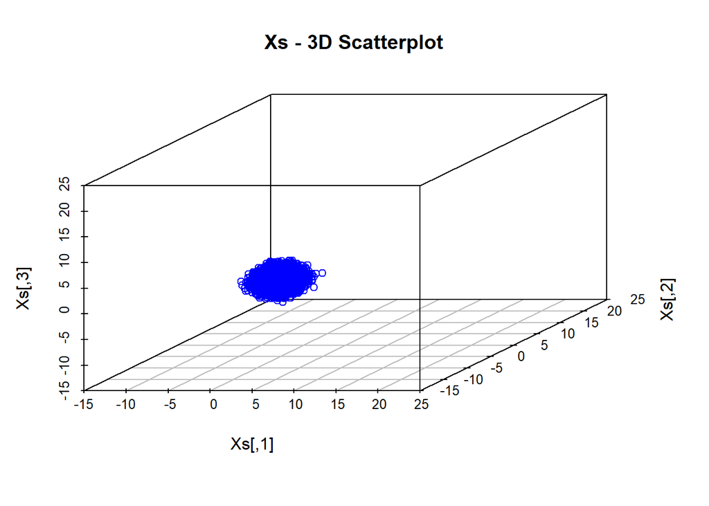

```r
scatterplot3d(Xs, xlim=xyz.lim, ylim=xyz.lim, zlim=xyz.lim, highlight.3d=FALSE, main="Xs - 3D Scatterplot", color="blue" );
```

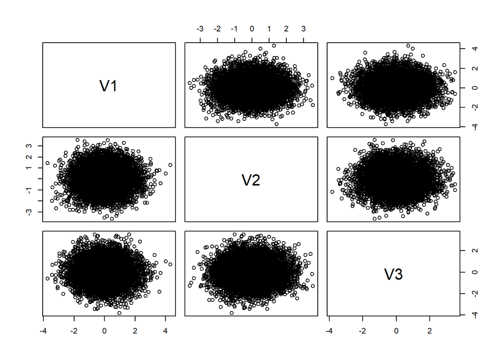

```r
# this is interactive, and will open in its own window
plot3d(Xs, xlim=xyz.lim, ylim=xyz.lim, zlim=xyz.lim, main="Xs - 3D plot",col="blue" );

graphics::plot( as.data.frame(Xs) );
```

It is called “scaling” for a reason. A translation in the (x,y) to “mean-center” at zero. And a scaling factor of (x,y) … e.g., our z-scores.

### 2.2.2 Rotated

We can take that same data and rotate it … eventually we will call this `phi` … currently, hardcoded as $\phi = 60$ in degrees, so I have the helper functions which I have placed in `functions-maths.R`.

```r
XR = X; # let's manually rotate 60 ...

x = X[,1];
y = X[,2];
z = X[,3];

# rotate around z-axis by angle phi
# https://stackoverflow.com/questions/20759214/
r = sqrt(x*x + y*y);
theta = atan(y/x);
phi = deg2rad(60);
# (r * cos(theta + phi), r * sin(theta + phi))

XR[,1] = r * cos(theta + phi);  # x
XR[,1] = r * sin(theta + phi);  # y


xyzr.lim = c(min(XR),max(XR));


print("################   XR   ################");
```

```
## [1] "################   XR   ################"
```

```r
print(paste0("MEANS:    x = ",round(mean(XR[,1]),3),
                "       y = ",round(mean(XR[,2]),3),
                "       z = ",round(mean(XR[,3]),3)));
```

```
## [1] "MEANS:    x = 2.007       y = 3.043       z = 7.94"
```

```r
print(paste0("VARIANCE: x = ",round(var(XR[,1]),3),
                "       y = ",round(var(XR[,2]),3),
                "       z = ",round(var(XR[,3]),3)));
```

```
## [1] "VARIANCE: x = 9.005       y = 22.924       z = 12.666"
```

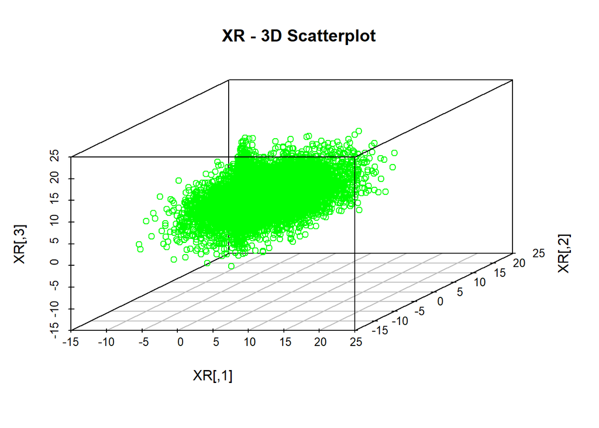

```r
scatterplot3d(XR, xlim=xyzr.lim, ylim=xyzr.lim, zlim=xyzr.lim, highlight.3d=FALSE, main="XR - 3D Scatterplot", color="green");
```

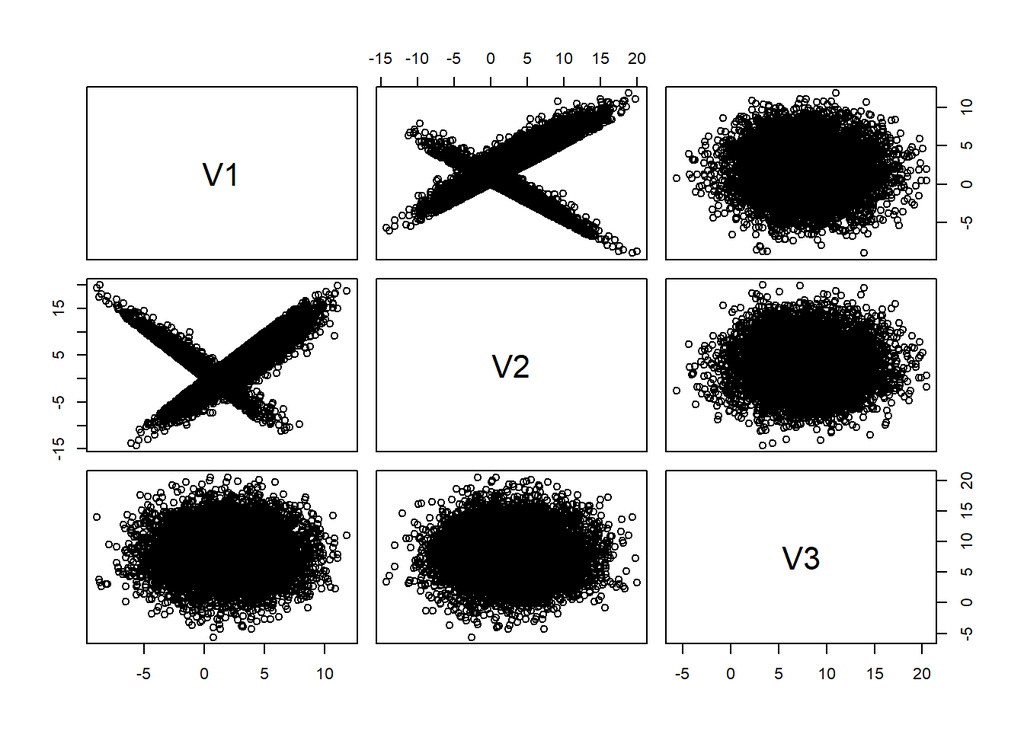

```r
# this is interactive, and will open in its own window
plot3d(XR, xlim=xyzr.lim, ylim=xyzr.lim, zlim=xyzr.lim, main="XR - 3D plot", col="green");


graphics::plot( as.data.frame(XR) );
```

```r
XRs = scale(XR);


print("################   XRs   ################");
```

```
## [1] "################   XRs   ################"
```

```r
print(paste0("MEANS:    x = ",round(mean(XRs[,1]),3),
                "       y = ",round(mean(XRs[,2]),3),
                "       z = ",round(mean(XRs[,3]),3)));
```

```
## [1] "MEANS:    x = 0       y = 0       z = 0"
```

```r
print(paste0("VARIANCE: x = ",round(var(XRs[,1]),3),
                "       y = ",round(var(XRs[,2]),3),
                "       z = ",round(var(XRs[,3]),3)));
```

```
## [1] "VARIANCE: x = 1       y = 1       z = 1"
```

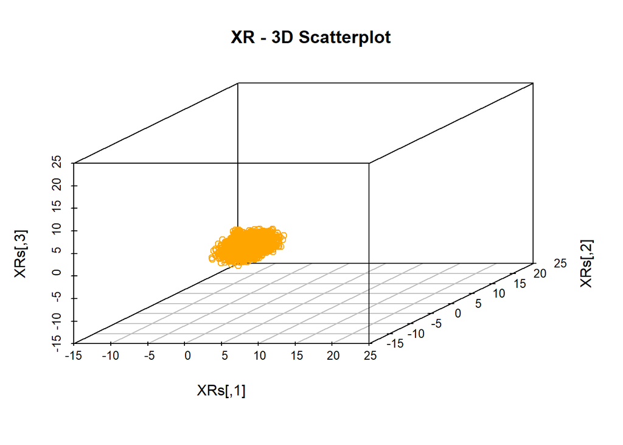

```r
scatterplot3d(XRs, xlim=xyzr.lim, ylim=xyzr.lim, zlim=xyzr.lim, highlight.3d=FALSE, main="XR - 3D Scatterplot", color="orange");
```

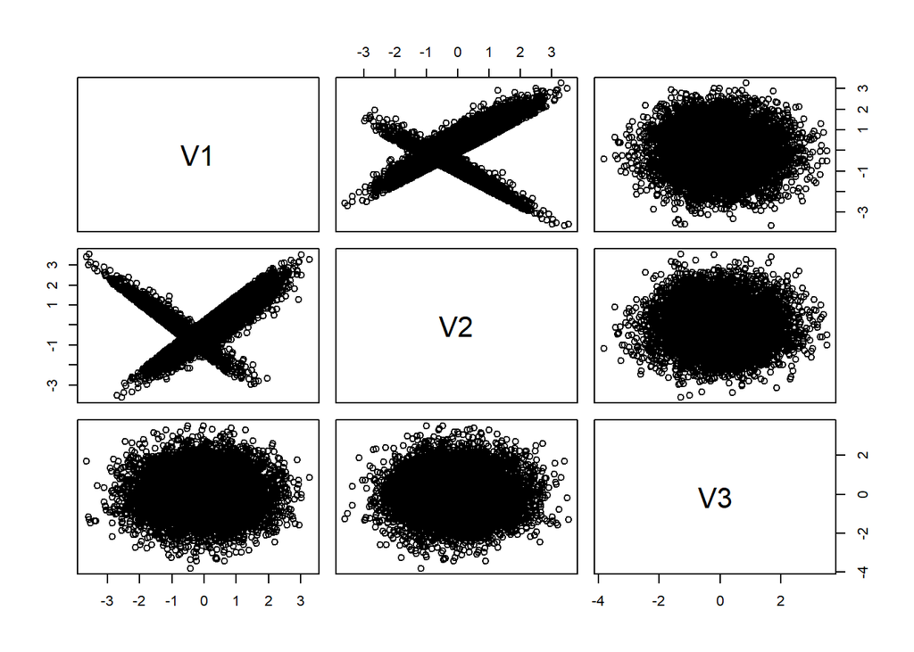

```r
# this is interactive, and will open in its own window
plot3d(XRs, xlim=xyzr.lim, ylim=xyzr.lim, zlim=xyzr.lim, main="XR - 3D plot", col="orange");

graphics::plot( as.data.frame(XRs) );
```

Translations, scalings, and rotations are not changing the overall basis.

### 2.2.3 Principle Components Analysis of Xs

If we don’t scale, the one dimension will outweigh another dimension. This will create uninterpretable results.

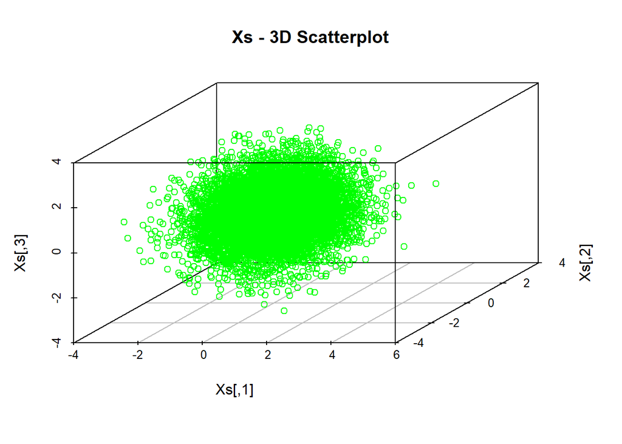

```r
scatterplot3d(Xs, highlight.3d=FALSE, main="Xs - 3D Scatterplot", color="green" );
```

```r
Xs.PCA = princomp(Xs);

summary(Xs.PCA);
```

```
## Importance of components:
##                           Comp.1    Comp.2    Comp.3
## Standard deviation     1.0069151 1.0003637 0.9925025
## Proportion of Variance 0.3379969 0.3336129 0.3283902
## Cumulative Proportion  0.3379969 0.6716098 1.0000000
```

```r
str(Xs.PCA);
```

```
## List of 7
##  $ sdev    : Named num [1:3] 1.007 1 0.993
##   ..- attr(*, "names")= chr [1:3] "Comp.1" "Comp.2" "Comp.3"
##  $ loadings: 'loadings' num [1:3, 1:3] 0.7167 0.3038 -0.6277 0.0389 0.8813 ...
##   ..- attr(*, "dimnames")=List of 2
##   .. ..$ : NULL
##   .. ..$ : chr [1:3] "Comp.1" "Comp.2" "Comp.3"
##  $ center  : num [1:3] 0.0000000000000000712 0.0000000000000000191 -0.0000000000000000486
##  $ scale   : num [1:3] 1 1 1
##  $ n.obs   : int 9000
##  $ scores  : num [1:9000, 1:3] 1.069 -0.247 1.002 -0.542 0.342 ...
##   ..- attr(*, "dimnames")=List of 2
##   .. ..$ : NULL
##   .. ..$ : chr [1:3] "Comp.1" "Comp.2" "Comp.3"
##  $ call    : language princomp(x = Xs)
##  - attr(*, "class")= chr "princomp"
```

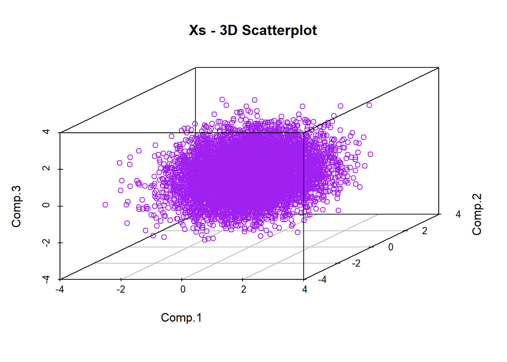

```r
Xs.PCA.scores = Xs.PCA$scores;

scatterplot3d(Xs.PCA.scores, highlight.3d=FALSE, main="Xs - 3D Scatterplot", color="purple" );
```

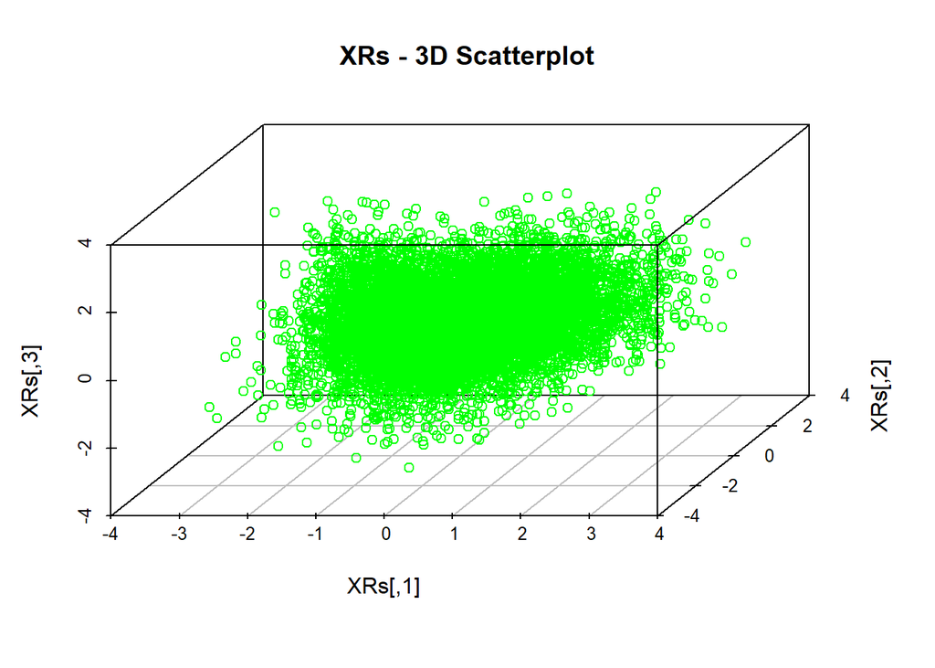

```r
scatterplot3d(XRs, highlight.3d=FALSE, main="XRs - 3D Scatterplot", color="green" );
```

```r
XRs.PCA = princomp(XRs);

summary(XRs.PCA);
```

```
## Importance of components:
##                           Comp.1    Comp.2    Comp.3
## Standard deviation     1.1890519 0.9999577 0.7654455
## Proportion of Variance 0.4713338 0.3333422 0.1953240
## Cumulative Proportion  0.4713338 0.8046760 1.0000000
```

```r
str(XRs.PCA);
```

```
## List of 7
##  $ sdev    : Named num [1:3] 1.189 1 0.765
##   ..- attr(*, "names")= chr [1:3] "Comp.1" "Comp.2" "Comp.3"
##  $ loadings: 'loadings' num [1:3, 1:3] 0.70712 0.70706 -0.00761 0.00243 -0.01319 ...
##   ..- attr(*, "dimnames")=List of 2
##   .. ..$ : NULL
##   .. ..$ : chr [1:3] "Comp.1" "Comp.2" "Comp.3"
##  $ center  : num [1:3] 0.0000000000000000739 0.0000000000000000191 -0.0000000000000000486
##  $ scale   : num [1:3] 1 1 1
##  $ n.obs   : int 9000
##  $ scores  : num [1:9000, 1:3] 1.4111 -0.1523 0.0802 -0.842 -0.0758 ...
##   ..- attr(*, "dimnames")=List of 2
##   .. ..$ : NULL
##   .. ..$ : chr [1:3] "Comp.1" "Comp.2" "Comp.3"
##  $ call    : language princomp(x = XRs)
##  - attr(*, "class")= chr "princomp"
```

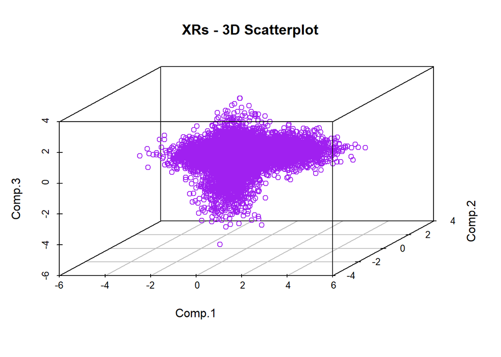

```r
XRs.PCA.scores = XRs.PCA$scores;

scatterplot3d(XRs.PCA.scores, highlight.3d=FALSE, main="XRs - 3D Scatterplot", color="purple" );
```

## 2.3 n-Dimensions

We could continue this for many dimensions. After 3-D, we have an issue with plotting them all at the same time.

`graphics::plot( as.data.frame(XRs) );`

We can do pairwise plots with the above.

# 3 A Data Example

This includes athletic records for 55 countries in each of 8 track and field events. This was likely in the 1980s, but is still a nice learning example.

## 3.1 Change path to dataset

```r
## DROPBOX ... __student_access__ ...
## You need to change this ...
path.dataset = "C:/Users/Alexander Nevsky/Dropbox/WSU-419/Fall 2020/__student_access__/sample_latex_files/Multivariate-2009/datasets/";

file.running = paste0(path.dataset,"RECORDS.csv");
myData = read.csv(file.running,header=FALSE);
  colnames(myData)=c("Country","100m","200m","400m",
                               "800m","1500m","5000m",
                              "10000m","marathon");

myData;
```

| Country | 100m | 200m | 400m | 800m | 1500m | 5000m | 10000m | marathon |
| --- | --- | --- | --- | --- | --- | --- | --- | --- |
| Argentina | 10.39 | 20.81 | 46.84 | 1.81 | 3.70 | 14.04 | 29.36 | 137.72 |
| Australia | 10.31 | 20.06 | 44.84 | 1.74 | 3.57 | 13.28 | 27.66 | 128.30 |
| Austria | 10.44 | 20.81 | 46.82 | 1.79 | 3.60 | 13.26 | 27.72 | 135.90 |
| Belgium | 10.34 | 20.68 | 45.04 | 1.73 | 3.60 | 13.22 | 27.45 | 129.95 |
| Bermuda | 10.28 | 20.58 | 45.91 | 1.80 | 3.75 | 14.68 | 30.55 | 146.62 |
| Brazil | 10.22 | 20.43 | 45.21 | 1.73 | 3.66 | 13.62 | 28.62 | 133.13 |
| Burma | 10.64 | 21.52 | 48.30 | 1.80 | 3.85 | 14.45 | 30.28 | 139.95 |
| Canada | 10.17 | 20.22 | 45.68 | 1.76 | 3.63 | 13.55 | 28.09 | 130.15 |
| Chile | 10.34 | 20.80 | 46.20 | 1.79 | 3.71 | 13.62 | 29.30 | 134.03 |
| China | 10.51 | 21.04 | 47.30 | 1.81 | 3.73 | 13.90 | 29.13 | 133.53 |

[output cut: 45 more lines]

```r
X = (myData[,-1]);
Xs = scale(X);

rownames(X) = rownames(Xs) = myData[,1]; # We still have the country names, important when we get to biplot

# Xs;


performKMOTest(Xs);
```

```
## $KMO
## [1] 0.871196
##
## $msg
## [1] "meritorious!"
```

```r
performBartlettSphericityTest(Xs);
```

```
## $pvalue
## [1] 0.000000000000000000000000000000000000000000000000000000000000000000000000000000000000000000000000000000000000007288624
##
## $msg
## [1] "Bartlett's test of sphericity ... pvalue < alpha ... 0.00000000000000000000000000000000000000000000000000000000000000000000000000000000000000000000000000000000000000728862355419708 < 0.05 ... \n CONCLUSION: we believe this data is likely suitable for factor analysis or PCA"
```

## 3.2 Matrix Maths

```r
source_url( paste0(path.github, "humanVerseWSU/R/functions-str.R") );  # printMatrix
```

```
## SHA-1 hash of file is ee336fea935eb0180dba01db715a321a40515891
```

```r
n = nrow(Xs); n;  # number of observations
```

```
## [1] 55
```

```r
m = ncol(Xs); m;  # number of features
```

```
## [1] 8
```

```r
# let's use this syntax ... https://en.wikipedia.org/wiki/Principal_component_analysis


# why does covariance equal correlation
# it's scaled
# isClose deals with rounding/floating-point issues
print("Comparing covariance and correlation of Xs");
```

```
## [1] "Comparing covariance and correlation of Xs"
```

```r
isClose( as.numeric( cov(Xs) ), as.numeric( cor(Xs) ) );
```

```
##  [1] TRUE TRUE TRUE TRUE TRUE TRUE TRUE TRUE TRUE TRUE TRUE TRUE TRUE TRUE TRUE
## [16] TRUE TRUE TRUE TRUE TRUE TRUE TRUE TRUE TRUE TRUE TRUE TRUE TRUE TRUE TRUE
## [31] TRUE TRUE TRUE TRUE TRUE TRUE TRUE TRUE TRUE TRUE TRUE TRUE TRUE TRUE TRUE
## [46] TRUE TRUE TRUE TRUE TRUE TRUE TRUE TRUE TRUE TRUE TRUE TRUE TRUE TRUE TRUE
## [61] TRUE TRUE TRUE TRUE
```

```r
# cor(Xs) or cor(X)

S = ( transposeMatrix(as.matrix(Xs)) %*% as.matrix(Xs)) / (n-1);
dim(S);
```

```
## [1] 8 8
```

```r
print("Comparing S and the covariance of Xs");
```

```
## [1] "Comparing S and the covariance of Xs"
```

```r
isClose( as.numeric( S ), as.numeric( cov(Xs) ) );
```

```
##  [1] TRUE TRUE TRUE TRUE TRUE TRUE TRUE TRUE TRUE TRUE TRUE TRUE TRUE TRUE TRUE
## [16] TRUE TRUE TRUE TRUE TRUE TRUE TRUE TRUE TRUE TRUE TRUE TRUE TRUE TRUE TRUE
## [31] TRUE TRUE TRUE TRUE TRUE TRUE TRUE TRUE TRUE TRUE TRUE TRUE TRUE TRUE TRUE
## [46] TRUE TRUE TRUE TRUE TRUE TRUE TRUE TRUE TRUE TRUE TRUE TRUE TRUE TRUE TRUE
## [61] TRUE TRUE TRUE TRUE
```

```r
S.eigen = eigen(S); # eigenvalues again
str(S.eigen);
```

```
## List of 2
##  $ values : num [1:8] 6.004 1.039 0.551 0.138 0.109 ...
##  $ vectors: num [1:8, 1:8] -0.323 -0.146 -0.369 -0.387 -0.393 ...
##  - attr(*, "class")= chr "eigen"
```

```r
Lambda = S.eigen$values;
length(Lambda);   # notice it is of length "m"
```

```
## [1] 8
```

```r
# S - Lambda * I, its determinant
round( det(S - diag(Lambda)), digits=4);
```

```
## [1] 0
```

```r
D = diag(Lambda);  # Lambda * I
printMatrix(D, 5);
```

```
##      [,1]      [,2]      [,3]      [,4]      [,5]      [,6]      [,7]
## [1,] "6.00426" "0"       "0"       "0"       "0"       "0"       "0"
## [2,] "0"       "1.03903" "0"       "0"       "0"       "0"       "0"
## [3,] "0"       "0"       "0.55148" "0"       "0"       "0"       "0"
## [4,] "0"       "0"       "0"       "0.13785" "0"       "0"       "0"
## [5,] "0"       "0"       "0"       "0"       "0.10872" "0"       "0"
## [6,] "0"       "0"       "0"       "0"       "0"       "0.07696" "0"
## [7,] "0"       "0"       "0"       "0"       "0"       "0"       "0.05712"
## [8,] "0"       "0"       "0"       "0"       "0"       "0"       "0"
##      [,8]
## [1,] "0"
## [2,] "0"
## [3,] "0"
## [4,] "0"
## [5,] "0"
## [6,] "0"
## [7,] "0"
## [8,] "0.02457"
```

```r
D.sqrt = diag(sqrt(Lambda));
D.sqrt;
```

```
##          [,1]    [,2]      [,3]      [,4]      [,5]      [,6]      [,7]
## [1,] 2.450359 0.00000 0.0000000 0.0000000 0.0000000 0.0000000 0.0000000
## [2,] 0.000000 1.01933 0.0000000 0.0000000 0.0000000 0.0000000 0.0000000
## [3,] 0.000000 0.00000 0.7426153 0.0000000 0.0000000 0.0000000 0.0000000
## [4,] 0.000000 0.00000 0.0000000 0.3712804 0.0000000 0.0000000 0.0000000
## [5,] 0.000000 0.00000 0.0000000 0.0000000 0.3297324 0.0000000 0.0000000
## [6,] 0.000000 0.00000 0.0000000 0.0000000 0.0000000 0.2774204 0.0000000
## [7,] 0.000000 0.00000 0.0000000 0.0000000 0.0000000 0.0000000 0.2390073
## [8,] 0.000000 0.00000 0.0000000 0.0000000 0.0000000 0.0000000 0.0000000
##           [,8]
## [1,] 0.0000000
## [2,] 0.0000000
## [3,] 0.0000000
## [4,] 0.0000000
## [5,] 0.0000000
## [6,] 0.0000000
## [7,] 0.0000000
## [8,] 0.1567533
```

```r
printMatrix(D.sqrt, 5);
```

```
##      [,1]      [,2]      [,3]      [,4]      [,5]      [,6]      [,7]
## [1,] "2.45036" "0"       "0"       "0"       "0"       "0"       "0"
## [2,] "0"       "1.01933" "0"       "0"       "0"       "0"       "0"
## [3,] "0"       "0"       "0.74262" "0"       "0"       "0"       "0"
## [4,] "0"       "0"       "0"       "0.37128" "0"       "0"       "0"
## [5,] "0"       "0"       "0"       "0"       "0.32973" "0"       "0"
## [6,] "0"       "0"       "0"       "0"       "0"       "0.27742" "0"
## [7,] "0"       "0"       "0"       "0"       "0"       "0"       "0.23901"
## [8,] "0"       "0"       "0"       "0"       "0"       "0"       "0"
##      [,8]
## [1,] "0"
## [2,] "0"
## [3,] "0"
## [4,] "0"
## [5,] "0"
## [6,] "0"
## [7,] "0"
## [8,] "0.15675"
```

```r
W = S.eigen$vectors;  # orthogonal unit vectors
dim(W);
```

```
## [1] 8 8
```

```r
T = Xs %*% W;
dim(T);
```

```
## [1] 55  8
```

```r
# The transpose of W is sometimes called the whitening or sphering transformation.
#round( transposeMatrix(W), digits=2);  # https://en.wikipedia.org/wiki/Whitening_transformation
printMatrix( transposeMatrix(W) , 5);
```

```
##      [,1]       [,2]       [,3]       [,4]       [,5]       [,6]
## [1,] "-0.32267" "-0.14563" "-0.3691"  "-0.38652" "-0.3933"  "-0.3862"
## [2,] "-0.382"   "-0.83737" "-0.08773" "0.02629"  "0.06835"  "0.17924"
## [3,] "-0.55604" "0.5075"   "-0.43354" "-0.15423" "0.07048"  "0.23249"
## [4,] "-0.48351" "0.06708"  "0.06157"  "0.63796"  "0.35283"  "-0.05184"
## [5,] "0.42333"  "-0.10204" "-0.7895"  "0.30287"  "0.22402"  "-0.18809"
## [6,] "0.04919"  "-0.05831" "-0.05031" "-0.49338" "0.51316"  "0.3067"
## [7,] "-0.07764" "0.00583"  "0.16748"  "-0.26452" "0.58119"  "-0.66265"
## [8,] "-0.13905" "0.04119"  "0.10215"  "0.11835"  "-0.24474" "-0.43981"
##      [,7]       [,8]
## [1,] "-0.38934" "-0.36555"
## [2,] "0.18655"  "0.26999"
## [3,] "0.21056"  "0.34376"
## [4,] "-0.23638" "-0.40973"
## [5,] "0.09881"  "-0.00364"
## [6,] "0.23851"  "-0.57788"
## [7,] "-0.0791"  "0.33582"
## [8,] "0.80031"  "-0.24637"
```

```r
VAF = round(Lambda / traceMatrix(S), digits=4);
VAF.cumsum = cumsum(VAF);

# loadings  ??
F = as.matrix(W) %*% D.sqrt;
dim(F);
```

```
## [1] 8 8
```

```r
Z = ( W %*% D %*% transposeMatrix(W) );  # (n-1) is built into each component ...
dim(Z);
```

```
## [1] 8 8
```

```r
isClose(S, Z);
```

```
##  [1] TRUE TRUE TRUE TRUE TRUE TRUE TRUE TRUE TRUE TRUE TRUE TRUE TRUE TRUE TRUE
## [16] TRUE TRUE TRUE TRUE TRUE TRUE TRUE TRUE TRUE TRUE TRUE TRUE TRUE TRUE TRUE
## [31] TRUE TRUE TRUE TRUE TRUE TRUE TRUE TRUE TRUE TRUE TRUE TRUE TRUE TRUE TRUE
## [46] TRUE TRUE TRUE TRUE TRUE TRUE TRUE TRUE TRUE TRUE TRUE TRUE TRUE TRUE TRUE
## [61] TRUE TRUE TRUE TRUE
```

## 3.3 Summary of Some Maths

```r
Answer = round( rbind(F, rep(NA,times=8), Lambda, VAF, VAF.cumsum)
            ,digits=4);
  rownames(Answer) =
                c("100m","200m","400m","800m",
                  "1500m","5000m","10000m","marathon",
                  "", "EIGEN","% VAF", "C. % VAF");
#Answer;

printMatrix(Answer, 4);
```

```
##          [,1]      [,2]      [,3]      [,4]      [,5]      [,6]      [,7]
## 100m     "-0.7907" "-0.3894" "-0.4129" "-0.1795" "0.1396"  "0.0136"  "-0.0186"
## 200m     "-0.3569" "-0.8536" "0.3769"  "0.0249"  "-0.0336" "-0.0162" "0.0014"
## 400m     "-0.9044" "-0.0894" "-0.322"  "0.0229"  "-0.2603" "-0.014"  "0.04"
## 800m     "-0.9471" "0.0268"  "-0.1145" "0.2369"  "0.0999"  "-0.1369" "-0.0632"
## 1500m    "-0.9637" "0.0697"  "0.0523"  "0.131"   "0.0739"  "0.1424"  "0.1389"
## 5000m    "-0.9463" "0.1827"  "0.1727"  "-0.0192" "-0.062"  "0.0851"  "-0.1584"
## 10000m   "-0.954"  "0.1902"  "0.1564"  "-0.0878" "0.0326"  "0.0662"  "-0.0189"
## marathon "-0.8957" "0.2752"  "0.2553"  "-0.1521" "-0.0012" "-0.1603" "0.0803"
##          NA        NA        NA        NA        NA        NA        NA
## EIGEN    "6.0043"  "1.039"   "0.5515"  "0.1378"  "0.1087"  "0.077"   "0.0571"
## % VAF    "0.7505"  "0.1299"  "0.0689"  "0.0172"  "0.0136"  "0.0096"  "0.0071"
## C. % VAF "0.7505"  "0.8804"  "0.9493"  "0.9665"  "0.9801"  "0.9897"  "0.9968"
##          [,8]
## 100m     "-0.0218"
## 200m     "0.0065"
## 400m     "0.016"
## 800m     "0.0186"
## 1500m    "-0.0384"
## 5000m    "-0.0689"
## 10000m   "0.1255"
## marathon "-0.0386"
##          NA
## EIGEN    "0.0246"
## % VAF    "0.0031"
## C. % VAF "0.9999"
```

## 3.4 Run PCA

```r
Xs.princomp = stats::princomp(Xs);
  summary(Xs.princomp);   # , loadings=TRUE);
```

```
## Importance of components:
##                           Comp.1    Comp.2     Comp.3     Comp.4     Comp.5
## Standard deviation     2.4279804 1.0100212 0.73583333 0.36788968 0.32672113
## Proportion of Variance 0.7505322 0.1298793 0.06893469 0.01723115 0.01359044
## Cumulative Proportion  0.7505322 0.8804115 0.94934615 0.96657729 0.98016773
##                             Comp.6      Comp.7      Comp.8
## Standard deviation     0.274886821 0.236824556 0.155321763
## Proportion of Variance 0.009620259 0.007140562 0.003071451
## Cumulative Proportion  0.989787987 0.996928549 1.000000000
```

```r
Xs.prcomp = stats::prcomp(Xs);
  summary(Xs.prcomp);
```

```
## Importance of components:
##                           PC1    PC2     PC3     PC4     PC5     PC6     PC7
## Standard deviation     2.4504 1.0193 0.74262 0.37128 0.32973 0.27742 0.23901
## Proportion of Variance 0.7505 0.1299 0.06893 0.01723 0.01359 0.00962 0.00714
## Cumulative Proportion  0.7505 0.8804 0.94935 0.96658 0.98017 0.98979 0.99693
##                            PC8
## Standard deviation     0.15675
## Proportion of Variance 0.00307
## Cumulative Proportion  1.00000
```

```r
Xs.prcomp.E = zeroIsh ( cov(Xs.prcomp$x) );  # better than zapsmall

printMatrix(Xs.prcomp.E, 4);
```

```
##     PC1      PC2     PC3      PC4      PC5      PC6     PC7      PC8
## PC1 "6.0043" "0"     "0"      "0"      "0"      "0"     "0"      "0"
## PC2 "0"      "1.039" "0"      "0"      "0"      "0"     "0"      "0"
## PC3 "0"      "0"     "0.5515" "0"      "0"      "0"     "0"      "0"
## PC4 "0"      "0"     "0"      "0.1378" "0"      "0"     "0"      "0"
## PC5 "0"      "0"     "0"      "0"      "0.1087" "0"     "0"      "0"
## PC6 "0"      "0"     "0"      "0"      "0"      "0.077" "0"      "0"
## PC7 "0"      "0"     "0"      "0"      "0"      "0"     "0.0571" "0"
## PC8 "0"      "0"     "0"      "0"      "0"      "0"     "0"      "0.0246"
```

```r
  #Xs.prcomp.E;


Xs.prcomp.lambda = diag(Xs.prcomp.E);
Xs.prcomp.lambda;
```

```
##        PC1        PC2        PC3        PC4        PC5        PC6        PC7
## 6.00425735 1.03903427 0.55147755 0.13784916 0.10872349 0.07696208 0.05712450
##        PC8
## 0.02457161
```

```r
# From matrix "maths"  ... Equal except for some rounding errors ...
Lambda;
```

```
## [1] 6.00425735 1.03903427 0.55147755 0.13784916 0.10872349 0.07696208 0.05712450
## [8] 0.02457161
```

```r
zeroIsh( Lambda - Xs.prcomp.lambda );
```

```
## PC1 PC2 PC3 PC4 PC5 PC6 PC7 PC8
##   0   0   0   0   0   0   0   0
```

```r
# isClose is a much more precise comparison ... based on floating-point issues
# zeroIsh is just dropping values very close to zero as a form of 1/10^digits of accuracy
```

## 3.5 Variance Accounted For (VAF)

The first dimension is selected to maximize explaining the data. The proportion or percentage of variance explained for that dimension is reported (`% VAF`).

The second dimension is selected to be orthogonal to the first dimension. The proportion or percentage of variance explained for that dimension is reported (`% VAF`). And the cumulative proportion or percentage of variance is also recorded (`C. % VAF`).

The third dimension is selected to be orthogonal to the first and second dimension. The proportion or percentage of variance explained for that dimension is reported (`% VAF`). And the cumulative proportion or percentage of variance is also recorded (`C. % VAF`).

And, so on.

## 3.6 Dimension Selection

So how many dimensions are “good enough”? There are a few common “rules of thumb”.

### 3.6.1 Kaiser rule

Choose `Lambda` values that are greater than one; that is eigenvalues greater than one.

“The advantage of the rule is that it is easy to calculate, especially if you live in the 1950s, and don’t have access to a fast computer.” https://stats.stackexchange.com/questions/253535/

### 3.6.2 Common “G” factor

When 80% of the variance is accounted for. That is the (`C. % VAF`) reaches `0.800` or higher.

### 3.6.3 Scree Plotting (e.g., similar to Exploratory Factor Analysis)

```r
source_url( paste0(path.github, "humanVerseWSU/R/functions-EDA.R") );   # how many factors
```

```
## SHA-1 hash of file is 6bd5154c16ec52b82f168904395cc551799c0c7f
```

```r
Xs.how.many = howManyFactorsToSelect(Xs);
```

```
## [1] "  Paralell Analysis"
```

```
## Parallel analysis suggests that the number of factors =  1  and the number of components =  NA
## [1] "============================================="
## [1] "  VSS Analysis"
```

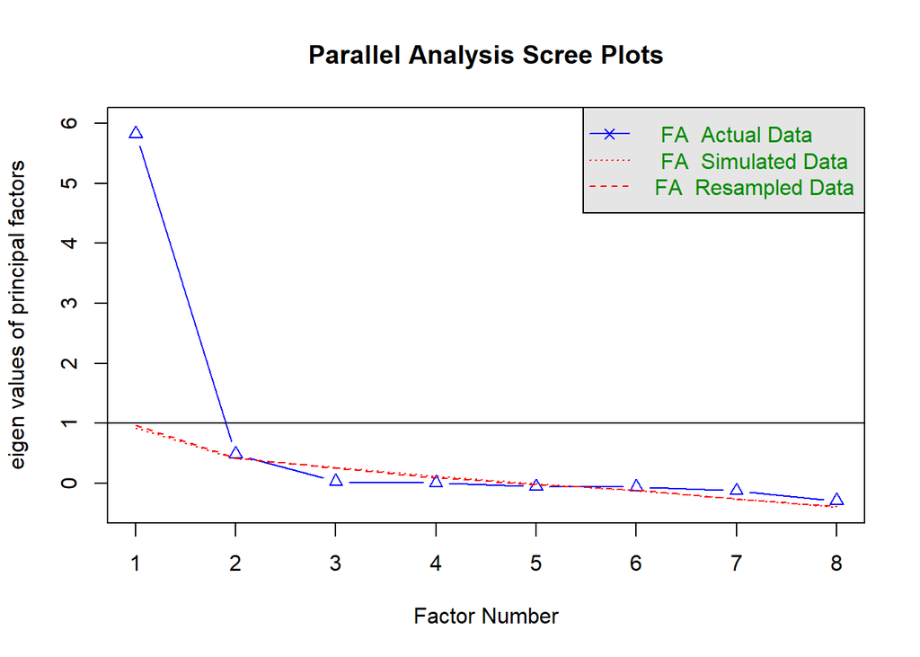

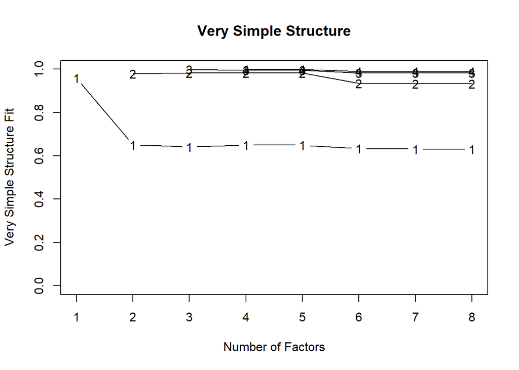

```
## [1] "************************"
## [1] "  Eigenvalues >= 1   ...  [ n = 2 ]"
## [1] 6.004257 1.039034
## [1] "************************"
```

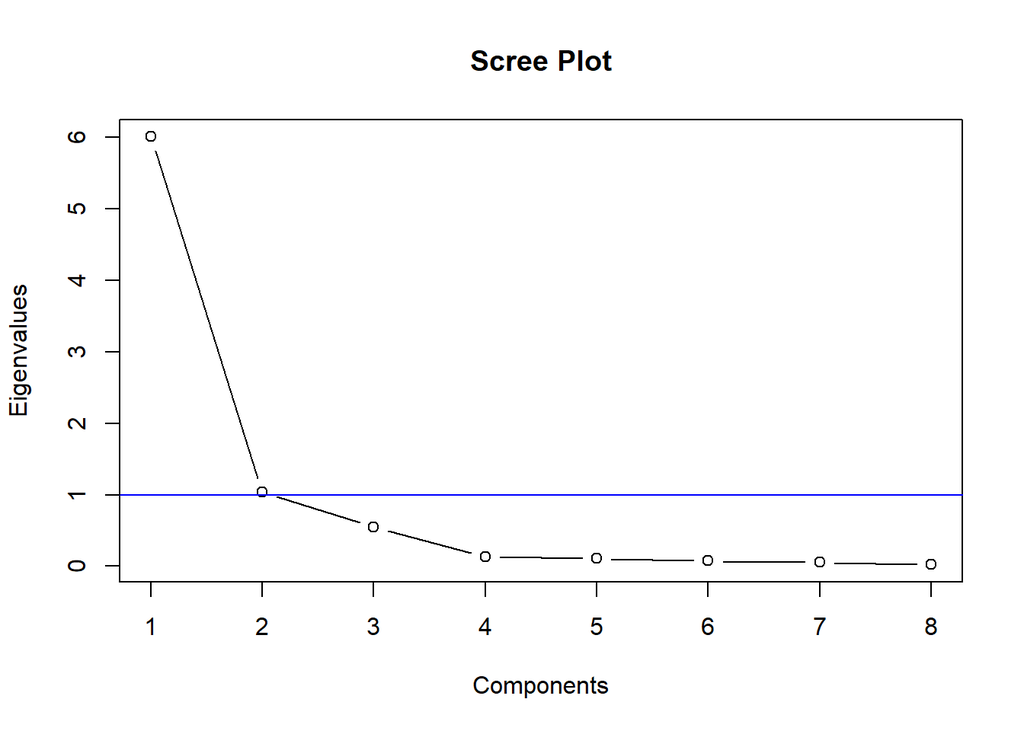

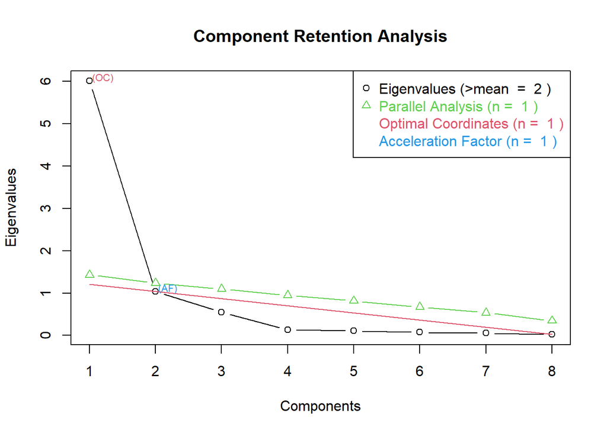

```
## [1] "A 1-Factor solution has the most votes!"
## [1] ""
## [1] "Due to Optimal Coordinantes and Parallel Analysis Agreement,"
## [1] "A 1-Factor solution is *strongly* recommended!"
## [1] "************************"
## [1] "  Final Analysis of VSS, Eigen, nFactors"
##   Factor vote.count
## 1      1          4
## 2      2          2
## [1] ""
```

## 3.7 More Maths

The nature of PCA is similar to SVD. https://math.stackexchange.com/questions/3869/what-is-the-intuitive-relationship-between-svd-and-pca

Computationally, computing the $S$ matrix (covariance) is expensive. SVD is less expensive, so for larger matrices, it is a best approach.

The “loadings” are a function of $W$ (the “eigen” vectors): `W = S.eigen$vectors`

The “weights” of each component is based on its “eigen” values $\lambda_i$s. Review what `Lambda / sum(Lambda)` would generate.

$$D = \lambda I$$
a matrix with the diagonal elements containing the $\lambda_i$s.

We have $m = 1, 2, 3, ... 8$ maximum components because that’s the maximum number of dimensions we can rotate if we started with 8 features …

This is a nice video explaining the importance of the vector maths. https://www.youtube.com/watch?v=mBcLRGuAFUk

## 3.8 Orthogonal Nature of W

Consider the matrix $W$.

We computed $T = X \cdot W$. https://en.wikipedia.org/wiki/Principal_component_analysis

```r
dim(Xs);  # data
```

```
## [1] 55  8
```

```r
dim(S);   # sample variance (correlation if Xs)
```

```
## [1] 8 8
```

```r
dim(W);   # the eigenvectors associated with
```

```
## [1] 8 8
```

```r
length(Lambda);
```

```
## [1] 8
```

```r
n;
```

```
## [1] 55
```

```r
m;
```

```
## [1] 8
```

```r
dim(T);
```

```
## [1] 55  8
```

```r
# what do you notice ??? ... orthogonality
zapsmall( W %*% transposeMatrix(W), digits=2);
```

```
##      [,1] [,2] [,3] [,4] [,5] [,6] [,7] [,8]
## [1,]    1    0    0    0    0    0    0    0
## [2,]    0    1    0    0    0    0    0    0
## [3,]    0    0    1    0    0    0    0    0
## [4,]    0    0    0    1    0    0    0    0
## [5,]    0    0    0    0    1    0    0    0
## [6,]    0    0    0    0    0    1    0    0
## [7,]    0    0    0    0    0    0    1    0
## [8,]    0    0    0    0    0    0    0    1
```

```r
zapsmall( transposeMatrix(W) %*% W, digits=2);
```

```
##      [,1] [,2] [,3] [,4] [,5] [,6] [,7] [,8]
## [1,]    1    0    0    0    0    0    0    0
## [2,]    0    1    0    0    0    0    0    0
## [3,]    0    0    1    0    0    0    0    0
## [4,]    0    0    0    1    0    0    0    0
## [5,]    0    0    0    0    1    0    0    0
## [6,]    0    0    0    0    0    1    0    0
## [7,]    0    0    0    0    0    0    1    0
## [8,]    0    0    0    0    0    0    0    1
```

```r
zeroIsh( W %*% transposeMatrix(W) );
```

```
##      [,1] [,2] [,3] [,4] [,5] [,6] [,7] [,8]
## [1,]    1    0    0    0    0    0    0    0
## [2,]    0    1    0    0    0    0    0    0
## [3,]    0    0    1    0    0    0    0    0
## [4,]    0    0    0    1    0    0    0    0
## [5,]    0    0    0    0    1    0    0    0
## [6,]    0    0    0    0    0    1    0    0
## [7,]    0    0    0    0    0    0    1    0
## [8,]    0    0    0    0    0    0    0    1
```

```r
zeroIsh( transposeMatrix(W) %*% W );
```

```
##      [,1] [,2] [,3] [,4] [,5] [,6] [,7] [,8]
## [1,]    1    0    0    0    0    0    0    0
## [2,]    0    1    0    0    0    0    0    0
## [3,]    0    0    1    0    0    0    0    0
## [4,]    0    0    0    1    0    0    0    0
## [5,]    0    0    0    0    1    0    0    0
## [6,]    0    0    0    0    0    1    0    0
## [7,]    0    0    0    0    0    0    1    0
## [8,]    0    0    0    0    0    0    0    1
```

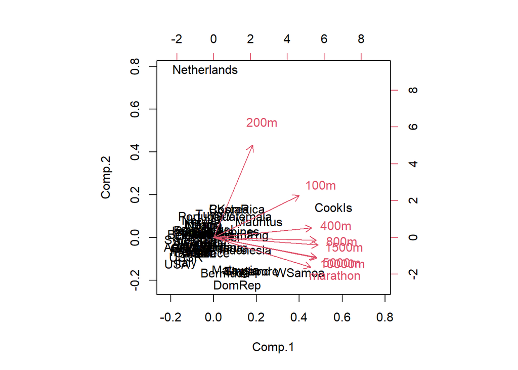

```r
biplot(Xs.princomp);  # equivalent to # biplot(Xs.prcomp);
biplot(Xs.princomp, 1:2);
```

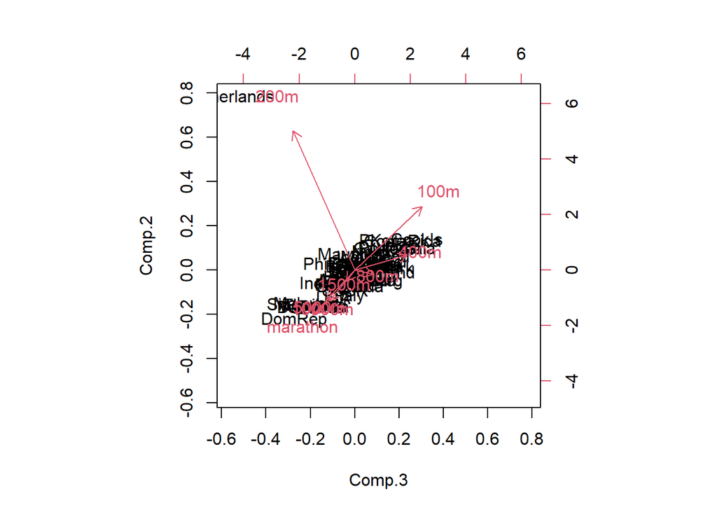

```r
biplot(Xs.princomp, 3:2);  # Netherlands and something with 200 meters
```

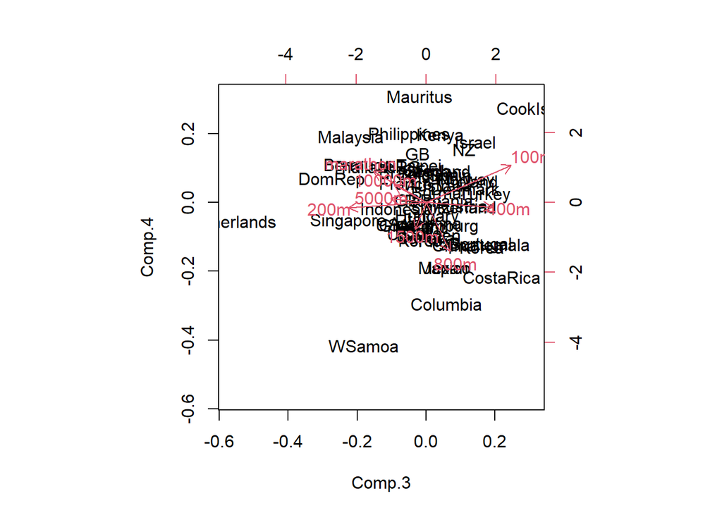

```r
biplot(Xs.princomp, 3:4);
```